# machine_learning

HD

2025-03-22

```r
library(xgboost)
library(SHAPforxgboost)
library(Matrix)
library(lattice)
library(pROC)
library(readxl)
library(dplyr)
library(showtext)
```

```r
library(ggplot2)
library(caret)  # 用于数据划分
library(nnet)
```

导入数据

```r
rm(list=ls())


tdata <- read_excel("../data/tuoye.xlsx", col_names = TRUE, row.names(TRUE) )
xdata <- read_excel("../data/xueqing.xlsx", col_names = TRUE, row.names(TRUE) )
tdata <- tdata[, !(names(tdata) %in% c("BV/TV", "Tb.Sp", "M1"))]
xdata <- xdata[, !(names(xdata) %in% c("BV/TV", "Tb.Sp", "M1"))]
```

# 唾液因子模型

首先筛选唾液因子

建立模型并且评估模型准确度：F1 score和accuracy

```r
tdata$group <- as.factor(tdata$group)

# 将 group 变量转换为数值 (C=0, M=1, S=2)
tdata$group <- as.numeric(tdata$group) - 1
```

```r
# 拆分为数据集和训练集
set.seed(123)
trainIndex <- createDataPartition(tdata$group, p = 0.7, list = FALSE)
trainData <- tdata[trainIndex, ]
testData <- tdata[-trainIndex, ]

#提取特征和标签
train_x_t <- as.matrix(trainData[, setdiff(names(tdata), "group")])
train_y_t <- trainData$group
test_x_t <- as.matrix(testData[, setdiff(names(tdata), "group")])
test_y_t <- testData$group


train_x_t <- train_x_t[, -1, drop = FALSE]
test_x_t <- test_x_t[, -1, drop = FALSE]

train_x_t <- data.matrix(train_x_t)  # 转换为数值型矩阵
test_x_t <- data.matrix(test_x_t)    # 转换为数值型矩阵
```

```r
test_x_t <- apply(test_x_t, 2, as.numeric)  # 把字符型转换成数值型
train_x_t <- apply(train_x_t, 2, as.numeric)

test_x_t <- matrix(as.numeric(unlist(test_x_t)), nrow = nrow(test_x_t), byrow = FALSE)
train_x_t <- matrix(as.numeric(unlist(train_x_t)), nrow = nrow(train_x_t), byrow = FALSE)

str(test_x_t)
```

```
##  num [1:4, 1:21] 863.9 1533.2 1252.2 1507.3 78.8 ...
```

```r
str(train_x_t)
```

```
##  num [1:14, 1:21] 1149 944 860 1305 630 ...
```

```r
dtrain_t <- xgb.DMatrix(data = train_x_t, label = train_y_t)
dtest_t <- xgb.DMatrix(data = test_x_t, label = test_y_t)
```

```r
# 设置xgboost参数

params <- list(
  objective = "multi:softprob", # 多分类任务
  num_class = 3,  #三个类别
  eval_metric = "mlogloss",
  eta = 0.3, #学习率
  max_depth = 5,  # 降低深度
  subsample = 0.7,  # 让每棵树看到部分数据
  colsample_bytree = 0.7  # 让每棵树用部分特征
)

#训练模型
t_model <- xgb.train(
  params = params,
  data = dtrain_t,
  nrounds = 100,  # 训练 100 轮
  watchlist = list(train = dtrain_t, test = dtest_t),
  print_every_n = 10
)
# 预测并计算准确率
pred_probs <- predict(t_model, dtest_t)
pred_matrix <- matrix(pred_probs, nrow = 3, byrow = TRUE)
pred_labels <- max.col(t(pred_matrix)) - 1


# 确保 pred_labels 和 test_y_t 都是因子，并且有相同的水平
pred_labels <- factor(pred_labels, levels = c(0, 1, 2))
test_y_t <- factor(test_y_t, levels = c(0, 1, 2))

# 计算 F1 Score
f1_score <- function(true, pred) {
  cm <- table(true, pred)
  precision <- diag(cm) / colSums(cm)
  recall <- diag(cm) / rowSums(cm)
  f1 <- 2 * (precision * recall) / (precision + recall)
  return(mean(f1, na.rm = TRUE))
}

f1_t <- f1_score(test_y_t, pred_labels)
print(paste("F1 Score:", round(f1_t, 4)))
```

```
## [1] "F1 Score: 0.7778"
```

```r
# 计算每个类别的 AUC
auc_values <- sapply(1:3, function(class) {
  if (sum(test_y_t == (class - 1)) > 0) {  # 检查当前类别的样本数量
    binary_response <- as.numeric(test_y_t == (class - 1))
    roc_curve <- roc(binary_response, pred_matrix[class, ])
    return(auc(roc_curve))
  } else {
    return(NA)  # 如果样本数量为 0，返回 NA
  }
})
print(paste("AUC for each class:", round(auc_values, 4)))
```

```
## [1] "AUC for each class: 1"    "AUC for each class: 0.75"
## [3] "AUC for each class: 1"
```

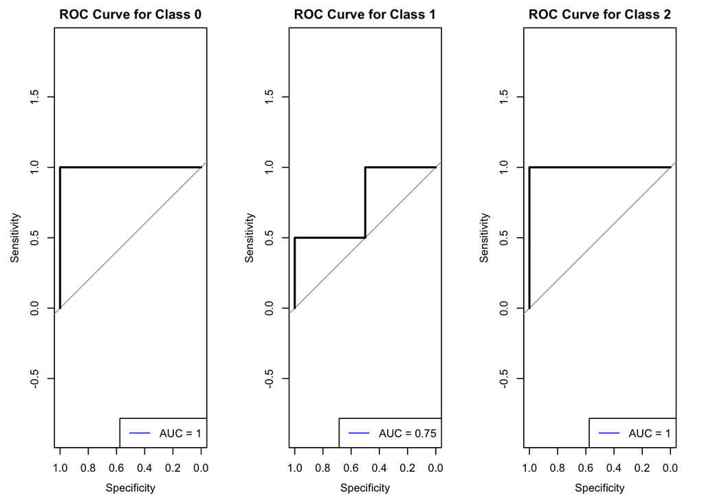

```r
# 绘制每个类别的 ROC 曲线
par(mfrow = c(1, 3))
for (class in 1:3) {
  if (sum(test_y_t == (class - 1)) > 0) {  # 检查当前类别的样本数量
    binary_response <- as.numeric(test_y_t == (class - 1))
    roc_curve <- roc(binary_response, pred_matrix[class, ])
    plot(roc_curve, main = paste("ROC Curve for Class", class - 1))
    auc_value <- auc(roc_curve)
    legend("bottomright", legend = paste("AUC =", round(auc_value, 4)), col = "blue", lty = 1)
  } else {
    plot(0, 0, type = "n", xlab = "", ylab = "", main = paste("Class", class - 1, "has no samples"))
  }
}
```

```r
#预测并计算准确率
# 预测结果是 3 类的概率，需要取最大概率的类别
pred_probs <- predict(t_model, dtest_t)
pred_matrix <- matrix(pred_probs, nrow = 3, byrow = TRUE)
pred_labels <- max.col(t(pred_matrix)) - 1  # 取概率最高的类别

# 计算准确率
t_accuracy <- sum(pred_labels == test_y_t) / length(test_y_t)
print(paste("测试集准确率:", round(t_accuracy, 4)))
```

```
## [1] "测试集准确率: 0.75"
```

```r
# 重要特征分析
importance_matrix_t <- xgb.importance(feature_names = colnames(train_x_t), model = t_model)
print(importance_matrix_t)
```

```
##     Feature         Gain       Cover  Frequency
##      <char>        <num>       <num>      <num>
##  1:      f1 3.443915e-01 0.265899163 0.24324324
##  2:      f0 2.766248e-01 0.208497665 0.18918919
##  3:      f2 1.835670e-01 0.150026524 0.16216216
##  4:     f16 8.409651e-02 0.118627422 0.10810811
##  5:      f4 3.704682e-02 0.027603658 0.02702703
##  6:      f3 2.975169e-02 0.037003711 0.04054054
##  7:     f17 1.698232e-02 0.040738053 0.04054054
##  8:     f12 1.669535e-02 0.066443486 0.08108108
##  9:     f13 5.929430e-03 0.009424754 0.01351351
## 10:      f5 2.189505e-03 0.021681156 0.02702703
## 11:      f6 1.947559e-03 0.023599186 0.02702703
## 12:     f14 7.114658e-04 0.010786185 0.01351351
## 13:     f18 3.775613e-05 0.009913932 0.01351351
## 14:     f10 2.828696e-05 0.009755105 0.01351351
```

```r
print(importance_matrix_t$Importance)
```

```r
write.csv(importance_matrix_t, "../result/importance_matrix_t.csv")
write.csv(importance_matrix_t$Importance, "../result/importance_matrix_t_importance.csv")
# 画出重要性图
xgb.plot.importance(importance_matrix_t)


mean_auc <- mean(auc_values)  # AUC 的平均值
mean_f1_accuracy_auc <- mean(c(f1_t, t_accuracy, mean_auc))  # F1、准确率和 AUC 的平均值
print(paste("Mean AUC:", round(mean_auc, 4)))
```

```
## [1] "Mean AUC: 0.9167"
```

```r
print(paste("Mean of F1, Accuracy, and AUC:", round(mean_f1_accuracy_auc, 4)))
```

```
## [1] "Mean of F1, Accuracy, and AUC: 0.8148"
```

[figure not shown]

# 血清因子模型

再筛选血清因子

```r
xdata$group <- as.factor(xdata$group)

# 将 group 变量转换为数值 (C=0, M=1, S=2)
xdata$group <- as.numeric(xdata$group) - 1
```

```r
# 拆分为数据集和训练集
set.seed(123)
trainIndex <- createDataPartition(tdata$group, p = 0.7, list = FALSE)
trainData <- xdata[trainIndex, ]
testData <- xdata[-trainIndex, ]

#提取特征和标签
train_x_x <- as.matrix(trainData[, setdiff(names(tdata), "group")])
train_y_x <- trainData$group
test_x_x <- as.matrix(testData[, setdiff(names(tdata), "group")])
test_y_x <- testData$group


train_x_x <- train_x_x[, -1, drop = FALSE]
test_x_x <- test_x_x[, -1, drop = FALSE]

train_x_x <- data.matrix(train_x_x)  # 转换为数值型矩阵
test_x_x <- data.matrix(test_x_x)    # 转换为数值型矩阵
```

```r
test_x_x <- apply(test_x_x, 2, as.numeric)  # 把字符型转换成数值型
train_x_x <- apply(train_x_x, 2, as.numeric)

test_x_x <- matrix(as.numeric(unlist(test_x_x)), nrow = nrow(test_x_x), byrow = FALSE)
train_x_x <- matrix(as.numeric(unlist(train_x_x)), nrow = nrow(train_x_x), byrow = FALSE)

str(test_x_x)
```

```
##  num [1:4, 1:21] 844.1 1318.8 1254.6 1972.8 57.2 ...
```

```r
str(train_x_x)
```

```
##  num [1:14, 1:21] 697 740 861 706 737 ...
```

```r
dtrain_x <- xgb.DMatrix(data = train_x_x, label = train_y_x)
dtest_x <- xgb.DMatrix(data = test_x_x, label = test_y_x)
```

```r
# 设置xgboost参数

params <- list(
  objective = "multi:softprob", # 多分类任务
  num_class = 3,  #三个类别
  eval_metric = "mlogloss",
  eta = 0.3, #学习率
  max_depth = 5,  # 降低深度
  subsample = 0.7,  # 让每棵树看到部分数据
  colsample_bytree = 0.7  # 让每棵树用部分特征
)

#训练模型
x_model <- xgb.train(
  params = params,
  data = dtrain_x,
  nrounds = 100,  # 训练 100 轮
  watchlist = list(train = dtrain_x, test = dtest_x),
  print_every_n = 10
)
# 预测并计算准确率
pred_probs <- predict(x_model, dtest_x)
pred_matrix <- matrix(pred_probs, nrow = 3, byrow = TRUE)
pred_labels <- max.col(t(pred_matrix)) - 1


# 确保 pred_labels 和 test_y 都是因子，并且有相同的水平
pred_labels <- factor(pred_labels, levels = c(0, 1, 2))
test_y_x <- factor(test_y_x, levels = c(0, 1, 2))

# 计算 F1 Score
f1_score <- function(true, pred) {
  cm <- table(true, pred)
  precision <- diag(cm) / colSums(cm)
  recall <- diag(cm) / rowSums(cm)
  f1 <- 2 * (precision * recall) / (precision + recall)
  return(mean(f1, na.rm = TRUE))
}

f1_x <- f1_score(test_y_x, pred_labels)
print(paste("F1 Score:", round(f1_x, 4)))
```

```
## [1] "F1 Score: 0.7778"
```

```r
# 计算每个类别的 AUC
auc_values <- sapply(1:3, function(class) {
  if (sum(test_y_x == (class - 1)) > 0) {  # 检查当前类别的样本数量
    binary_response <- as.numeric(test_y_x == (class - 1))
    roc_curve <- roc(binary_response, pred_matrix[class, ])
    return(auc(roc_curve))
  } else {
    return(NA)  # 如果样本数量为 0，返回 NA
  }
})
print(paste("AUC for each class:", round(auc_values, 4)))
```

```
## [1] "AUC for each class: 1" "AUC for each class: 1" "AUC for each class: 1"
```

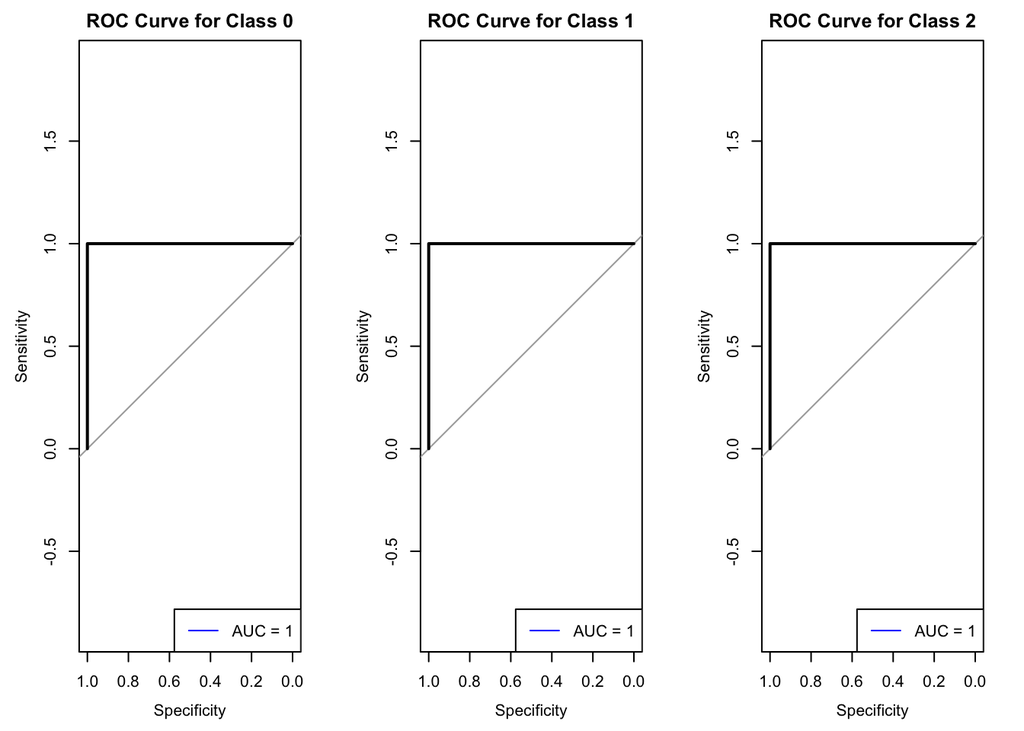

```r
# 绘制每个类别的 ROC 曲线
par(mfrow = c(1, 3))
for (class in 1:3) {
  if (sum(test_y_x == (class - 1)) > 0) {  # 检查当前类别的样本数量
    binary_response <- as.numeric(test_y_x == (class - 1))
    roc_curve <- roc(binary_response, pred_matrix[class, ])
    plot(roc_curve, main = paste("ROC Curve for Class", class - 1))
    auc_value <- auc(roc_curve)
    legend("bottomright", legend = paste("AUC =", round(auc_value, 4)), col = "blue", lty = 1)
  } else {
    plot(0, 0, type = "n", xlab = "", ylab = "", main = paste("Class", class - 1, "has no samples"))
  }
}
```

```r
mean_auc <- mean(auc_values)  # AUC 的平均值
mean_f1_accuracy_auc <- mean(c(f1_x, t_accuracy, mean_auc))  # F1、准确率和 AUC 的平均值
print(paste("Mean AUC:", round(mean_auc, 4)))
```

```
## [1] "Mean AUC: 1"
```

```r
print(paste("Mean of F1, Accuracy, and AUC:", round(mean_f1_accuracy_auc, 4)))
```

```
## [1] "Mean of F1, Accuracy, and AUC: 0.8426"
```

```r
#预测并计算准确率

# 预测结果是 3 类的概率，需要取最大概率的类别
pred_probs <- predict(x_model, dtest_x)
pred_matrix <- matrix(pred_probs, nrow = 3, byrow = TRUE)
pred_labels <- max.col(t(pred_matrix)) - 1  # 取概率最高的类别

# 计算准确率
x_accuracy <- sum(pred_labels == test_y_x) / length(test_y_x)
print(paste("测试集准确率:", round(x_accuracy, 4)))
```

```
## [1] "测试集准确率: 0.75"
```

```r
# 重要特征分析
importance_matrix_x <- xgb.importance(feature_names = colnames(train_x_x), model = x_model)
print(importance_matrix_x)
```

```
##    Feature         Gain      Cover  Frequency
##     <char>        <num>      <num>      <num>
## 1:      f0 0.6759199285 0.50097444 0.46774194
## 2:      f1 0.2046059788 0.26177348 0.27419355
## 3:      f2 0.0939403469 0.09989239 0.09677419
## 4:      f3 0.0177302692 0.05517858 0.06451613
## 5:     f19 0.0028559734 0.01482806 0.01612903
## 6:     f16 0.0024935358 0.01626638 0.01612903
## 7:      f8 0.0016493977 0.01269805 0.01612903
## 8:      f9 0.0008045697 0.03838861 0.04838710
```

```r
print(importance_matrix_x$Importance)
```

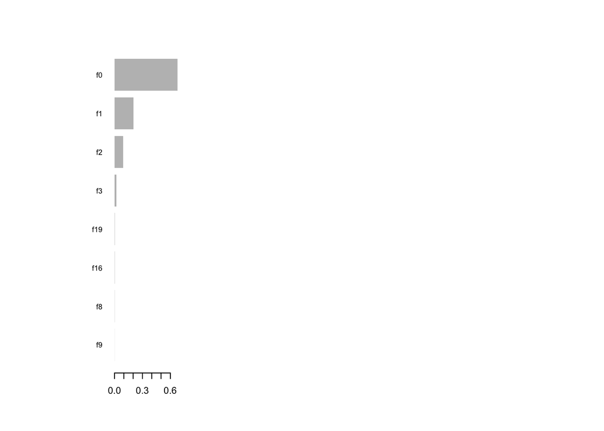

```r
write.csv(importance_matrix_x, "../result/importance_matrix_x.csv")
write.csv(importance_matrix_x$Importance, "../result/importance_matrix_x_importance.csv")

# 画出重要性图
xgb.plot.importance(importance_matrix_x)
```

# 交叉评估：比较三种分子在两种体液中的重要性

重要性比较

```r
top3_t <- importance_matrix_t %>% arrange(desc(Gain)) %>% head(3)
top3_x <- importance_matrix_x %>% arrange(desc(Gain)) %>% head(3)

# 添加来源信息
top3_t$Type <- "Saliva"
top3_x$Type <- "Serum"



# 合并数据
importance_combined <- rbind(top3_t, top3_x)

importance_combined <- importance_combined %>%
  mutate(Feature = recode(Feature,
                          "f0" = "MCP1",
                          "f1" = "TNFa",
                          "f2" = "CASP1"))


# 打印数据，确认格式
print(importance_combined)
```

```
##    Feature       Gain      Cover  Frequency Importance   Type
##     <char>      <num>      <num>      <num>      <num> <char>
## 1:    TNFa 0.34439152 0.26589916 0.24324324 0.34439152 Saliva
## 2:    MCP1 0.27662484 0.20849766 0.18918919 0.27662484 Saliva
## 3:   CASP1 0.18356695 0.15002652 0.16216216 0.18356695 Saliva
## 4:    MCP1 0.67591993 0.50097444 0.46774194 0.67591993  Serum
## 5:    TNFa 0.20460598 0.26177348 0.27419355 0.20460598  Serum
## 6:   CASP1 0.09394035 0.09989239 0.09677419 0.09394035  Serum
```

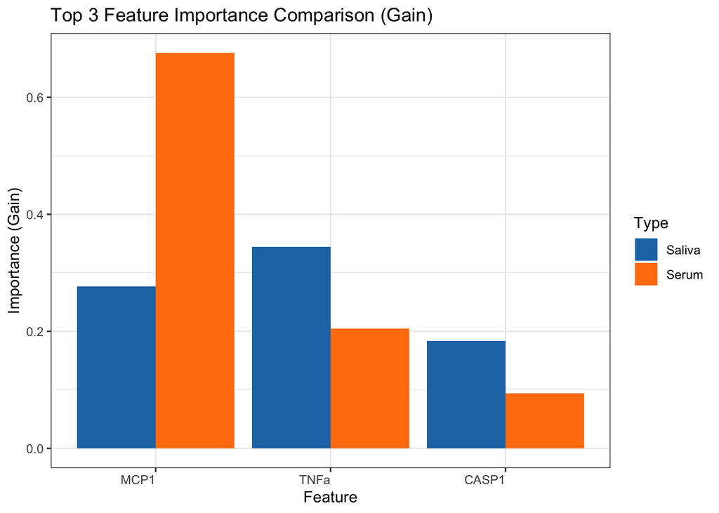

```r
ggplot(importance_combined, aes(x = reorder(Feature, -Gain), y = Gain, fill = Type)) +
  geom_bar(stat = "identity", position = "dodge") +
  theme_minimal() +
  theme_bw() +  # 设定白色背景
  labs(title = "Top 3 Feature Importance Comparison (Gain)",
       x = "Feature",
       y = "Importance (Gain)") +
  scale_fill_manual(values = c("Saliva" = "#1f77b4", "Serum" = "#ff7f0e")) +
  theme(axis.text.x = element_text(angle = 0, hjust = 1))
```

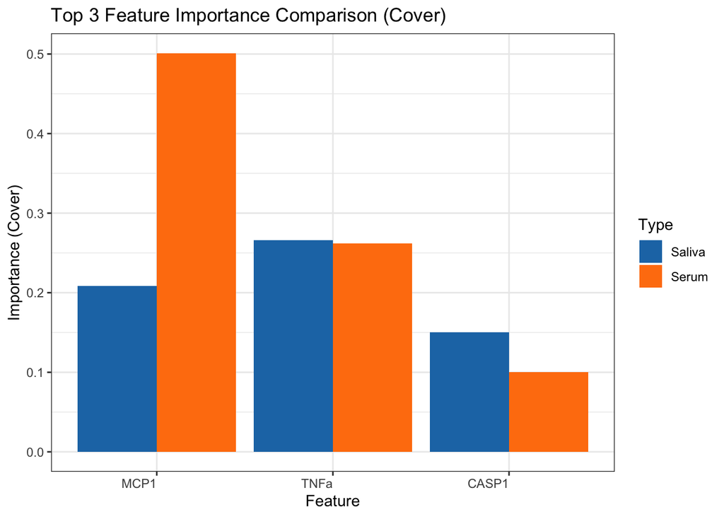

```r
ggsave("../visulization/因子重要性比较-Gain.png", width = 8, height = 6, dpi = 300)


ggplot(importance_combined, aes(x = reorder(Feature, -Cover), y = Cover, fill = Type)) +
  geom_bar(stat = "identity", position = "dodge") +
  theme_minimal() +
  theme_bw() +  # 设定白色背景
  labs(title = "Top 3 Feature Importance Comparison (Cover)",
       x = "Feature",
       y = "Importance (Cover)") +
  scale_fill_manual(values = c("Saliva" = "#1f77b4", "Serum" = "#ff7f0e")) +
  theme(axis.text.x = element_text(angle = 0, hjust = 1))
```

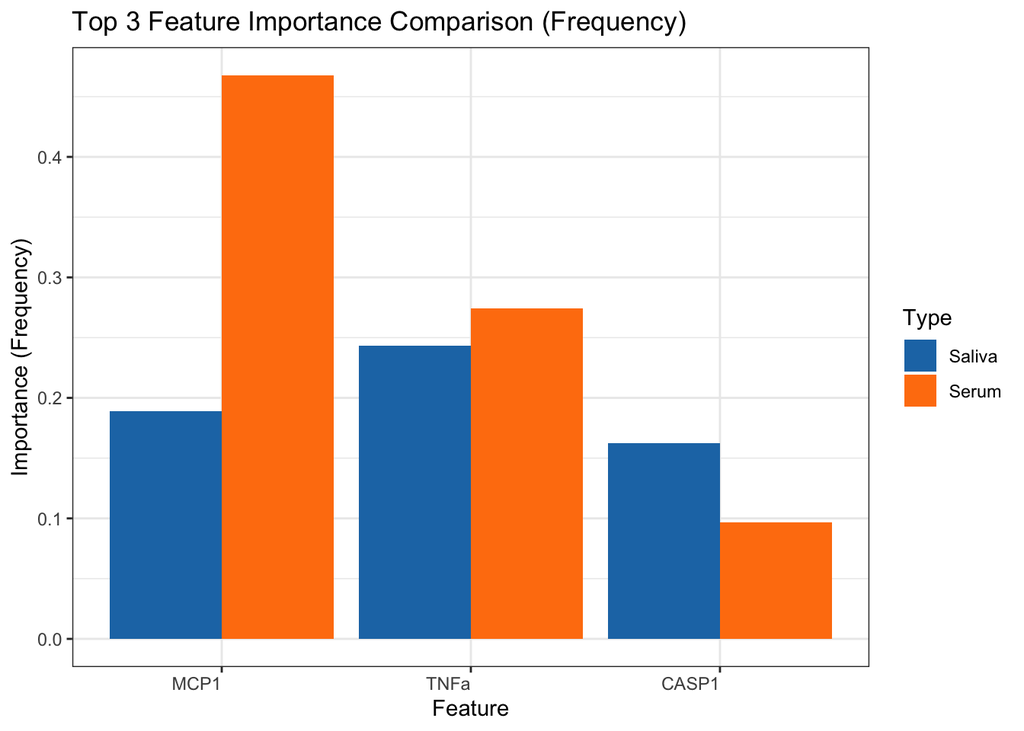

```r
ggsave("../visulization/因子重要性比较-Cover.png", width = 8, height = 6, dpi = 300)

ggplot(importance_combined, aes(x = reorder(Feature, -Frequency), y = Frequency, fill = Type)) +
  geom_bar(stat = "identity", position = "dodge") +
  theme_minimal() +
  theme_bw() +  # 设定白色背景
  labs(title = "Top 3 Feature Importance Comparison (Frequency)",
       x = "Feature",
       y = "Importance (Frequency)") +
  scale_fill_manual(values = c("Saliva" = "#1f77b4", "Serum" = "#ff7f0e")) +
  theme(axis.text.x = element_text(angle = 0, hjust = 1))
```

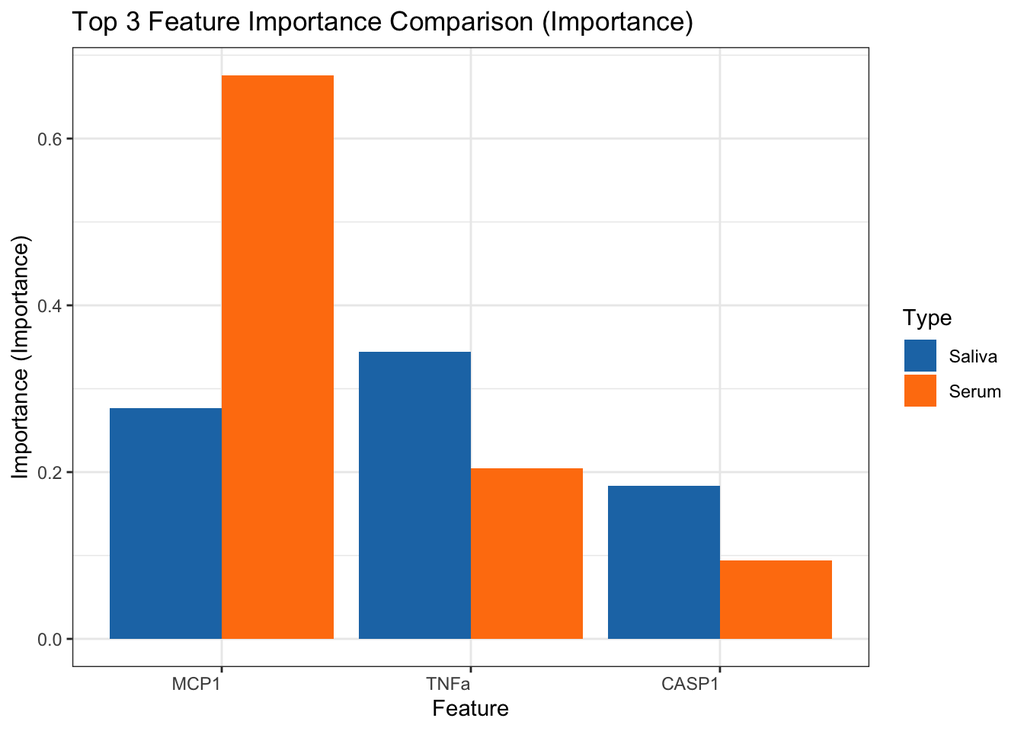

```r
ggsave("../visulization/因子重要性比较-frequency.png", width = 8, height = 6, dpi = 300)

ggplot(importance_combined, aes(x = reorder(Feature, -Importance), y = Importance, fill = Type)) +
  geom_bar(stat = "identity", position = "dodge") +
  theme_minimal() +
  theme_bw() +  # 设定白色背景
  labs(title = "Top 3 Feature Importance Comparison (Importance)",
       x = "Feature",
       y = "Importance (Importance)") +
  scale_fill_manual(values = c("Saliva" = "#1f77b4", "Serum" = "#ff7f0e")) +
  theme(axis.text.x = element_text(angle = 0, hjust = 1))
```

```r
ggsave("../visulization/因子重要性比较-importance.png", width = 8, height = 6, dpi = 300)
```

# 交叉验证

互换数据集预测 用唾液因子训练XGBoost模型，然后用血清数据测试，计算AUC等评估指标。 用血清因子训练XGBoost模型，然后用唾液数据测试，计算AUC等评估指标。

如果交叉测试的 AUC 下降不大，说明模型泛化性较强，血清和唾液数据可以互相代替，甚至可能合并数据训练一个更稳定的模型。 如果 AUC 下降很明显，说明数据来源差异较大，可能代表不同的生物过程，不能简单互换使用。这提示你可能需要针对不同数据源分别训练模型。 如果某个模型在两种数据上都表现较好，说明这种数据可能更稳定，预测能力更强。

```r
# 使用唾液模型 (t_model) 预测血清数据
pred_t_on_x <- predict(t_model, dtest_x)

# 由于 multi:softprob 输出的是每个类别的概率，需要转换为类别标签
pred_t_on_x_label <- max.col(matrix(pred_t_on_x, ncol = 3)) - 1

# 计算 AUC
auc_t_on_x <- multiclass.roc(test_y_x, pred_t_on_x_label)
# 使用血清模型 (x_model) 预测唾液数据
pred_x_on_t <- predict(x_model, dtest_t)

# 由于 multi:softprob 输出的是每个类别的概率，需要转换为类别标签
pred_x_on_t_label <- max.col(matrix(pred_x_on_t, ncol = 3)) - 1

# 计算 AUC
auc_x_on_t <- multiclass.roc(test_y_t, pred_x_on_t_label)
# 计算唾液模型 (t_model) 在血清数据上的准确率
accuracy_t_on_x <- mean(pred_t_on_x_label == test_y_x)


# 计算血清模型 (x_model) 在唾液数据上的准确率
accuracy_x_on_t <- mean(pred_x_on_t_label == test_y_t)



# 计算 F1 Score
f1_score <- function(true, pred) {
  cm <- table(true, pred)
  precision <- diag(cm) / colSums(cm)
  recall <- diag(cm) / rowSums(cm)
  f1 <- 2 * (precision * recall) / (precision + recall)
  return(mean(f1, na.rm = TRUE))
}


f1_t_on_x <- f1_score(test_y_t, pred_t_on_x_label)


f1_x_on_t <- f1_score(test_y_x, pred_x_on_t_label)





print(auc_t_on_x)
```

```
##
## Call:
## multiclass.roc.default(response = test_y_x, predictor = pred_t_on_x_label)
##
## Data: pred_t_on_x_label with 3 levels of test_y_x: 0, 1, 2.
## Multi-class area under the curve: 1
```

```r
print(auc_x_on_t)
```

```
##
## Call:
## multiclass.roc.default(response = test_y_t, predictor = pred_x_on_t_label)
##
## Data: pred_x_on_t_label with 3 levels of test_y_t: 0, 1, 2.
## Multi-class area under the curve: 0.9167
```

```r
print(accuracy_t_on_x)
```

```
## [1] 1
```

```r
print(accuracy_x_on_t)
```

```
## [1] 0.5
```

```r
print(paste("F1 Score t on x:", round(f1_t_on_x, 4)))
```

```
## [1] "F1 Score t on x: 1"
```

```r
print(paste("F1 Score x on t:", round(f1_x_on_t, 4)))
```

```
## [1] "F1 Score x on t: 0.75"
```

```r
# F1 Score 计算函数
f1_score <- function(true, pred) {
  cm <- table(true, pred)
  precision <- diag(cm) / colSums(cm)
  recall <- diag(cm) / rowSums(cm)
  f1 <- 2 * (precision * recall) / (precision + recall)
  return(mean(f1, na.rm = TRUE))
}

set.seed(123)

# 使用 5 折交叉验证
train_control <- trainControl(method = "cv", number = 5, savePredictions = "all", classProbs = TRUE)

# 创建模型
model <- train(
  group ~ .,  # 使用所有特征来预测 group
  data = xdata,
  method = "xgbTree",  # 使用 xgboost 的分类树模型
  trControl = train_control,
  tuneLength = 5,  # 自动选择最佳的参数组合
  metric = "F1"  # 选择适用于分类任务的评估指标
)
```

[output not shown]

[output cut: 1945 more lines]

[output not shown]

```r
# 查看交叉验证结果
print(model)
```

```
## eXtreme Gradient Boosting
##
## 18 samples
## 22 predictors
##
## No pre-processing
## Resampling: Cross-Validated (5 fold)
## Summary of sample sizes: 15, 14, 14, 15, 14
## Resampling results across tuning parameters:
##
##   eta  max_depth  colsample_bytree  subsample  nrounds  RMSE          Rsquared
##   0.3  1          0.6               0.500       50      0.0348468056  0.9989398
##   0.3  1          0.6               0.500      100      0.0366834561  0.9988962
##   0.3  1          0.6               0.500      150      0.0367288109  0.9988992
##   0.3  1          0.6               0.500      200      0.0367061297  0.9989005
##   0.3  1          0.6               0.500      250      0.0366733469  0.9988999
##   0.3  1          0.6               0.625       50      0.0180373739  0.9990701
##   0.3  1          0.6               0.625      100      0.0180256800  0.9990756
##   0.3  1          0.6               0.625      150      0.0180335035  0.9990756
##   0.3  1          0.6               0.625      200      0.0180253070  0.9990756
##   0.3  1          0.6               0.625      250      0.0180273183  0.9990756
##   0.3  1          0.6               0.750       50      0.0002943257  1.0000000
##   0.3  1          0.6               0.750      100      0.0002899678  1.0000000
##   0.3  1          0.6               0.750      150      0.0002768832  1.0000000
##   0.3  1          0.6               0.750      200      0.0002776966  1.0000000
##   0.3  1          0.6               0.750      250      0.0002774873  1.0000000
##   0.3  1          0.6               0.875       50      0.0002864460  1.0000000
##   0.3  1          0.6               0.875      100      0.0002873294  1.0000000
##   0.3  1          0.6               0.875      150      0.0002767212  1.0000000
##   0.3  1          0.6               0.875      200      0.0002742610  1.0000000
##   0.3  1          0.6               0.875      250      0.0002734046  1.0000000
##   0.3  1          0.6               1.000       50      0.0003075111  1.0000000
##   0.3  1          0.6               1.000      100      0.0003075503  1.0000000
##   0.3  1          0.6               1.000      150      0.0003075503  1.0000000
##   0.3  1          0.6               1.000      200      0.0003075503  1.0000000
##   0.3  1          0.6               1.000      250      0.0003075503  1.0000000
##   0.3  1          0.8               0.500       50      0.0186233202  0.9996748
##   0.3  1          0.8               0.500      100      0.0192877393  0.9996316
##   0.3  1          0.8               0.500      150      0.0193777895  0.9996228
##   0.3  1          0.8               0.500      200      0.0193985550  0.9996217
```

[output cut: 965 more lines]

```
##   0.0002882771
##   0.0002837189
##   0.0002491034
##   0.0002491180
##   0.0002491180
##   0.0002491180
##   0.0002491180
##
## Tuning parameter 'gamma' was held constant at a value of 0
## Tuning
##  parameter 'min_child_weight' was held constant at a value of 1
## RMSE was used to select the optimal model using the smallest value.
## The final values used for the model were nrounds = 100, max_depth = 1, eta
##  = 0.4, gamma = 0, colsample_bytree = 0.6, min_child_weight = 1 and subsample
##  = 0.75.
```

评价指标:

RMSE (均方根误差): 衡量模型预测值与实际值的差异，值越小越好。 R-squared (R²值): 反映模型拟合的好坏，值越接近1越好。 MAE (平均绝对误差): 衡量预测值与实际值的平均绝对差异，值越小越好。 模型表现: